# File organization best practices

Andrew Tran

**[Setting up a reproducible data analysis workflow in R](https://www.ire.org/events-and-training/event/3189/3643/)**

- *File organization best practices*
- [Intro to R Markdown](https://andrewbtran.github.io/NICAR/2018/workflow/docs/02-rmarkdown.html)
- [Github](https://andrewbtran.github.io/NICAR/2018/workflow/docs/03-integrating_github.html)
- [Creating functions and packages](https://andrewbtran.github.io/NICAR/2018/workflow/docs/04-creating_functions_packages.html)

The goal of reproducible data analysis is to tie specific instructions to data analysis and experimental data so that scholarship can be recreated, better understood and verified.

Let’s be consistent with the good practices of social science and research.

# Thanks

These are all things I picked up from browsing other presentations and repos.

Much thanks to [Jenny Bryan](https://github.com/jennybc) and [Joris Muller](http://blog.jom.link/) from whom I cobbled many of these ideas and practices from.

Also to BuzzFeed, FiveThirtyEight, ProPublica, Chicago Tribune, Los Angeles Times, and TrendCT.org

# Purpose

Why a clear data analysis workflow

- Check analysis and track errors (?)
- Share results with colleagues for stories or editing
- Send methodology to sources for bullet-proofing
- To easily adjust when presented with new data
- Easily switch between work environments (desktop and laptop)
- Scavenge and repurpose code in future projects

# Constraints

- Workflow has to be platform agnostic
- Easy to deploy for yourself and others
- Free open source software
- Input has to be real raw data in whatever format it is (and wherever it is)
- But have a backup for when internet is not accessible
- Output has to work – whether html, PDF, or web app
- IDE agnostic (be able to run it from a command line without Rstudio)

# Four components

1. Software
- R
- Rstudio
- Git for version control
2. Clear file organization
3. One R script to pull it all together
4. Hosting the html output internally or publicly with Github pages

# Use projects to organize

[figure not shown]

## Do not dump your scripts into a folder

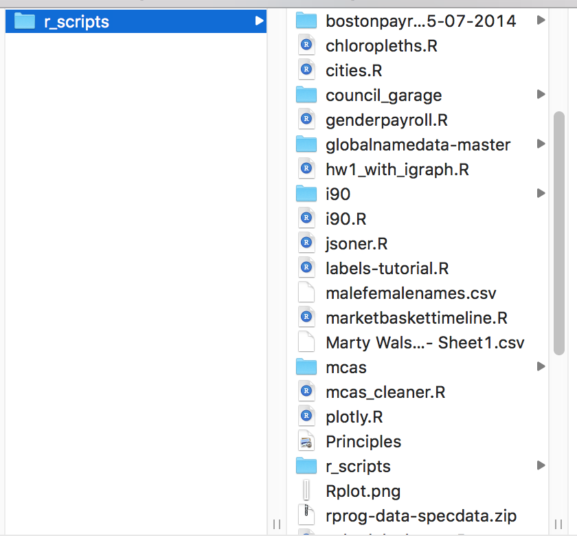

## One folder per project

- RStudio project
- Git repo
- Can run parallel projects

[figure not shown]